# 2020 Presidential Election - Twitter Sentiment Analysis

IST 736 - Final Project

- Thomas Marianos
- Gemma Miranda

## Introduction

The 2020 U.S. election was not the first in the social media age, but it did seem to spark more debate over social media tools and their role in influencing elections. Scrutiny over the candidates' use of Twitter as well as an investigation into Russian bot accounts used to spread misinformation dominated the news cycle for months. This analysis will take a look at Tweets with the hashtags #DonaldTrump and #JoeBiden to see if there was any indication of general sentiment supporting one or the other, as well as if we can predict the sentiment of a Tweet depending on who it is directed to.

The dataset used for this analysis is a Twitter Scrape found on Kaggle containing the tweet itself, the twitter handle, and other metadata about the tweet.

- created_at: Date and time of tweet creation
- tweet_id: Unique ID of the tweet
- tweet: Full tweet text
- likes: Number of likes
- retweet_count: Number of retweets
- source: Utility used to post tweet
- user_id: User ID of tweet creator
- user_name: Username of tweet creator
- user_screen_name: Screen name of tweet creator
- user_description: Description of self by tweet creator
- user_join_date: Join date of tweet creator
- user_followers_count: Followers count on tweet creator
- user_location: Location given on tweet creator's profile
- lat: Latitude parsed from user_location
- long: Longitude parsed from user_location
- city: City parsed from user_location
- country: Country parsed from user_location
- state: State parsed from user_location
- state_code: State code parsed from user_location
- collected_at: Date and time tweet data was mined from twitter*

With this dataset, we will develop and implement a Vader Sentiment analysis to find the overall sentiment behind each tweet and then compare a Multinomial Naive Bayes model against a Support Vector Machine model and see which performs best when predicting the sentiment.

Import Libraries

```python
%%capture
! pip install wordcloud
! pip install plotly
! pip install cufflinks

import pandas as pd
import numpy as np
import seaborn as sns
import re
from datetime import datetime
import time
import os
import io

import nltk
nltk.download('stopwords')
nltk.download('punkt')
from nltk import word_tokenize, FreqDist
from nltk.tokenize import TweetTokenizer
from nltk.corpus import stopwords
from nltk.stem.snowball import SnowballStemmer
from nltk.sentiment.vader import SentimentIntensityAnalyzer as vad
nltk.download('vader_lexicon')

import wordcloud
from wordcloud import WordCloud, STOPWORDS, ImageColorGenerator

import matplotlib.pyplot as plt
from plotly import graph_objs as go

from sklearn.preprocessing import LabelEncoder
from sklearn.feature_extraction.text import CountVectorizer, TfidfVectorizer
from sklearn.model_selection import train_test_split
from sklearn.metrics import confusion_matrix, accuracy_score, classification_report
from sklearn.naive_bayes import MultinomialNB
from sklearn.model_selection import cross_val_score
from sklearn.svm import LinearSVC
from sklearn import svm
```

Load in twitter data

```python
trump = pd.read_csv('/content/10k_hashtag_donaldtrump.csv')
biden = pd.read_csv('/content/10k_hashtag_joebiden.csv')
```

```python
trump['hashtag'] = 'Trump'
biden['hashtag'] = 'Biden'
tweets_df = pd.concat([trump, biden], axis = 0)
```

Clean Text

```python
tweets_df = tweets_df.drop(columns = [
                              'source',
                              'user_location',
                              'lat',
                              'long',
                              'continent',
                              'user_join_date',
                              'user_screen_name',
                              'user_description'])
```

```python
tweets_df['tweet']=tweets_df['tweet'].str.lower()
# # Proprocessing the data
#Code to remove the Hashtags from the text
tweets_df['tweet']=tweets_df['tweet'].apply(lambda x:re.sub(r'\B#\S+','',str(x)))
# Code to remove the links from the text
tweets_df['tweet']=tweets_df['tweet'].apply(lambda x:re.sub(r"http\S+", "", x))
# Code to remove the Special characters from the text
tweets_df['tweet']=tweets_df['tweet'].apply(lambda x:' '.join(re.findall(r'\w+', x)))
# Code to substitute the multiple spaces with single spaces
tweets_df['tweet']=tweets_df['tweet'].apply(lambda x:re.sub(r'\s+', ' ', x, flags=re.I))
# Code to remove all the single characters in the text
tweets_df['tweet']=tweets_df['tweet'].apply(lambda x:re.sub(r'\s+[a-zA-Z]\s+', '', x))
# Remove the twitter handlers
tweets_df['tweet']=tweets_df['tweet'].apply(lambda x:re.sub('@[^\s]+','',x))
```

```python
print(tweets_df.shape)
```

```
(20000, 14)
```

Define functions to further clean the data

```python
print("There are {:d} tweets collected from {:d} Twitter handles".format(tweets_df.shape[0],len(tweets_df['user_id'].unique())))
```

```
There are 20000 tweets collected from 6873 Twitter handles
```

Remove stopwords

```python
stop_words = stopwords.words('english', 'spanish')
stop_words.append('rt')
stop_words.append('amp')

tweets_df['tweet'] =  tweets_df['tweet'].apply(lambda x: ' '.join([word for word in x.split() if word not in (stop_words)]))
```

```python
trump = tweets_df[tweets_df['hashtag'] == 'Trump']
biden = tweets_df[tweets_df['hashtag'] == 'Biden']
```

## Data Exploration

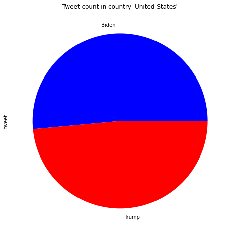

```python
plt.figure(figsize = (20,8))
country = "United States of America"
a = tweets_df[tweets_df.country == country].groupby('hashtag').tweet.count()
a.plot(x = 'hashtag', y = "tweet", kind = 'pie', title = "Tweet count in country 'United States'", colors = ['Blue', 'Red'])
```

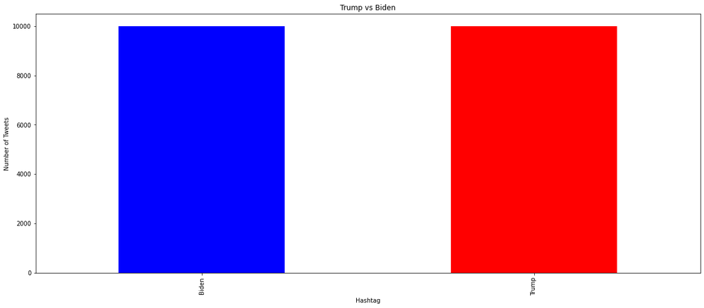

```python
plt.figure(figsize = (20,8))
tweets_df.groupby('hashtag')['tweet'].count().plot.bar(color = ['Blue', 'Red'])
plt.ylabel('Number of Tweets')
plt.xlabel('Hashtag')
plt.title('Trump vs Biden')
plt.show()
```

```python
top10states = tweets_df.groupby('state')['tweet'].count().sort_values(ascending=False).head(10).index.tolist()
state_df = tweets_df.groupby(['state','hashtag'])['tweet'].count().reset_index()
state_df = state_df[state_df['state'].isin(top10states)]
state_df
```

|  | state | hashtag | tweet |
| --- | --- | --- | --- |
| 64 | California | Biden | 418 |
| 65 | California | Trump | 492 |
| 111 | District of Columbia | Biden | 87 |
| 112 | District of Columbia | Trump | 101 |
| 121 | England | Biden | 141 |
| 122 | England | Trump | 220 |
| 129 | Florida | Biden | 321 |
| 130 | Florida | Trump | 265 |
| 167 | Ile-de-France | Biden | 112 |
| 168 | Ile-de-France | Trump | 161 |
| 169 | Illinois | Biden | 94 |
| 170 | Illinois | Trump | 101 |
| 261 | New Jersey | Biden | 99 |
| 262 | New Jersey | Trump | 75 |
| 267 | New York | Biden | 310 |
| 268 | New York | Trump | 376 |
| 305 | Pennsylvania | Biden | 80 |
| 306 | Pennsylvania | Trump | 97 |
| 403 | Texas | Biden | 326 |
| 404 | Texas | Trump | 206 |

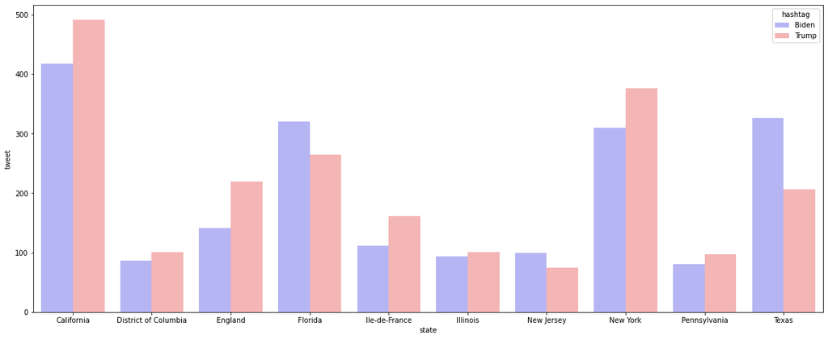

```python
plt.figure(figsize = (20,8))
sns.barplot(data = state_df,x='state',y = 'tweet',hue = 'hashtag', palette = "bwr")
plt.show()
```

## EDA

Define a tweet tokenizer and tokenize the tweet text

```python
tt = TweetTokenizer()

tweets_tt = tweets_df['tweet'].apply(tt.tokenize)
trump_tt = trump['tweet'].apply(tt.tokenize)
biden_tt = biden['tweet'].apply(tt.tokenize)
```

Define a function to stem tokenized tweets

```python
stemmer = SnowballStemmer('english', 'spanish')
```

```python
allTweets = []
stemmedTweets = []

for tweet in tweets_tt:
  newT = []
  for t in tweet:
    t = t.strip()
    allTweets.append(t.lower())
    newT.append(stemmer.stem(t.lower()))
    stemmedTweets.append(" ".join(newT))

tweets_all = " ".join(mt for mt in allTweets)
tweets_stem = " ".join(stt for stt in stemmedTweets)
```

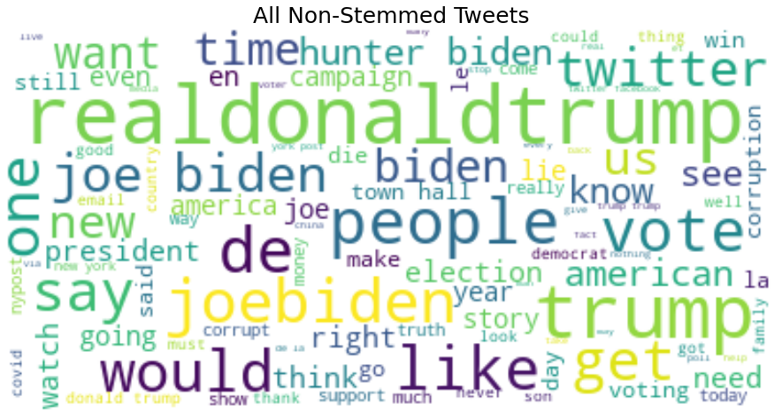

```python
plt.figure(figsize = (20,8))
allTweets = WordCloud(background_color = 'white', max_words = 100, stopwords = stop_words).generate(tweets_all)
plt.title('All Non-Stemmed Tweets', fontdict = {'fontsize' : 25})
plt.imshow(allTweets, interpolation = 'bilinear')
plt.axis('off')
plt.show()
```

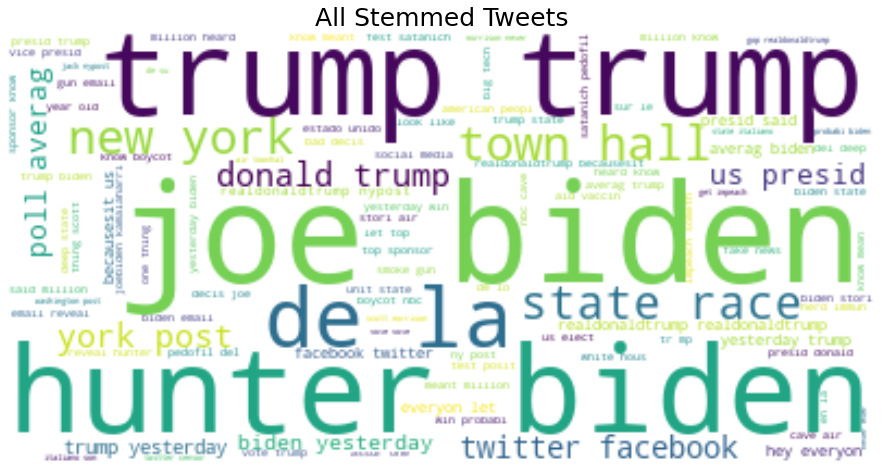

```python
plt.figure(figsize = (20,8))
stemTweets = WordCloud(background_color = 'white', max_words = 100, stopwords = stop_words).generate(tweets_stem)
plt.title('All Stemmed Tweets', fontdict = {'fontsize' : 25})
plt.imshow(stemTweets, interpolation = 'bilinear')
plt.axis('off')
plt.show()
```

Stem tokenized #DonaldTrump tweets

```python
allTrump = []
stemmedTrump = []

for tweet in trump_tt:
  newT = []
  for t in tweet:
    t = t.strip()
    allTrump.append(t.lower())
    newT.append(stemmer.stem(t.lower()))
    stemmedTrump.append(" ".join(newT))

trump_all = " ".join(mt for mt in allTrump)
trump_stem = " ".join(stt for stt in stemmedTrump)
```

Wordcloud for non-stemmed #DonaldTrump Tweets

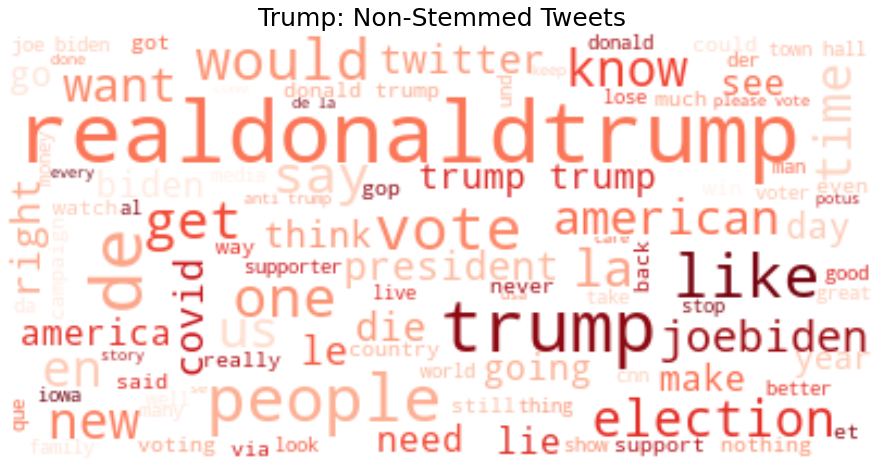

```python
plt.figure(figsize = (20,8))
allTrump = WordCloud(background_color = 'white', max_words = 100, colormap = 'Reds', stopwords = stop_words).generate(trump_all)
plt.title('Trump: Non-Stemmed Tweets', fontdict = {'fontsize' : 25})
plt.imshow(allTrump, interpolation = 'bilinear')
plt.axis('off')
plt.show()
```

Wordcloud for stemmed #DonaldTrump Tweets

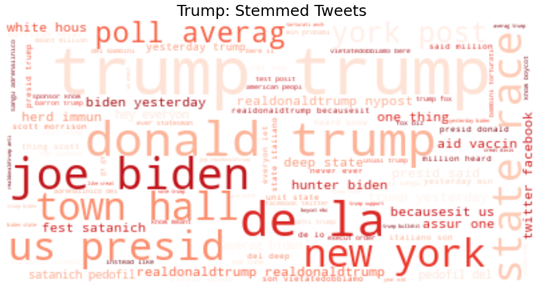

```python
plt.figure(figsize = (20,8))
stemTrump = WordCloud(background_color = 'white', max_words = 100, colormap = 'Reds', stopwords = stop_words).generate(trump_stem)
plt.title('Trump: Stemmed Tweets', fontdict = {'fontsize' : 25})
plt.imshow(stemTrump, interpolation = 'bilinear')
plt.axis('off')
plt.show()
```

Stem tokenized #JoeBiden tweets

```python
allBiden = []
stemmedBiden = []

for tweet in biden_tt:
  newT = []
  for t in tweet:
    t = t.strip()
    allBiden.append(t.lower())
    newT.append(stemmer.stem(t.lower()))
    stemmedBiden.append(" ".join(newT))

biden_all = " ".join(mt for mt in allBiden)
biden_stem = " ".join(stt for stt in stemmedBiden)
```

Wordcloud for non-stemmed #JoeBiden Tweets

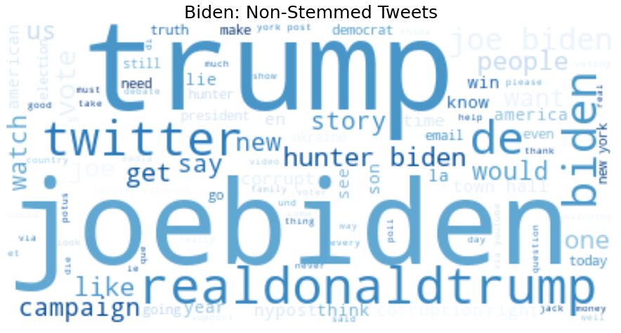

```python
plt.figure(figsize = (20,8))
allBiden = WordCloud(background_color = 'white', max_words = 100, colormap = 'Blues', stopwords = stop_words).generate(biden_all)
plt.title('Biden: Non-Stemmed Tweets', fontdict = {'fontsize' : 25})
plt.imshow(allBiden, interpolation = 'bilinear')
plt.axis('off')
plt.show()
```

Wordcloud for stemmed #JoeBiden Tweets

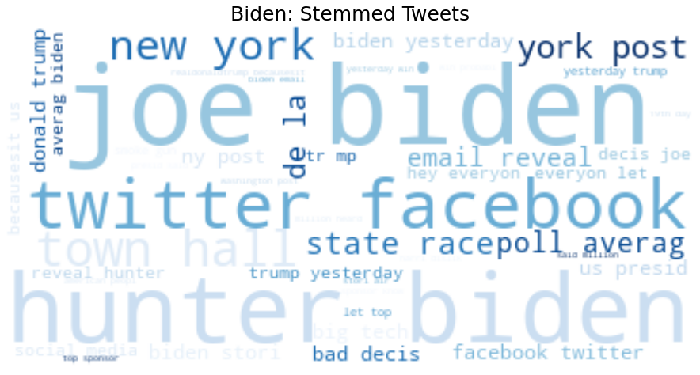

```python
plt.figure(figsize = (20,8))
stemBiden = WordCloud(background_color = 'white', max_words = 100, colormap = 'Blues', stopwords = stop_words).generate(biden_stem)
plt.title('Biden: Stemmed Tweets', fontdict = {'fontsize' : 25})
plt.imshow(stemBiden, interpolation = 'bilinear')
plt.axis('off')
plt.show()
```

Define functions to calculate tweet statistics

```python
def corpus_stats(documents):
    """Function to print tweet-level and corpus-level statistics
    These include
    - Average number of characters per tweet
    - Average number of words per tweet
    - Average vocabulary size per tweet
    - Average lexical richness per tweet
    - Total number of words
    - Total vocabulary size
    - Total lexical richness
    - Average number of characters per word

    Arguments:
        documents {[list]} -- [list of strings i.e. tweets]
    """
    docs = [word_tokenize(tweet) for tweet in documents]
    # tweet statistics
    print("observation level statistics:\n")
    # average number of characters per tweet
    avg_chars = int(sum([len(tweet) for tweet in documents]) / len(documents))
    print("Average number of characters per tweet: {:d}".format(avg_chars))
    # average number of words per tweet
    avg_words = int(sum([len(doc) for doc in docs]) / len(docs))
    print("Average number of words per tweet: {:d}".format(avg_words))
    # average vocabulary size per tweet
    avg_vocab = int(sum([len(set(doc)) for doc in docs]) / len(docs))
    print("Average vocabulary size per tweet: {:d}".format(avg_vocab))
    # average lexical richness per tweet (proportion of unique words to total words)
    avg_lex_rich = sum([len(set(doc))/len(doc) for doc in docs if len(doc) > 0]) / len(docs)
    print("Average lexical richness per tweet: {:.2f}".format(avg_lex_rich))
    # corpus statistics
    print("\nCorpus level statistics:\n")
    words = []
    for doc in docs:
        words.extend(doc)
    # total number of words
    print("Total number of words: {:d}".format(len(words)))
    # vocabulary size
    print("Total vocabulary size: {:d}".format(len(set(words))))
    # lexical richness
    print("Total lexical richness: {:.2f}".format(len(set(words)) / len(words)))
    # average number of characters per word
    word_lengths = [len(w) for w in words]
    print("Average number of characters per word: {:.2f}".format(sum(word_lengths) / len(word_lengths)))

def term_freq(documents):
    """Function to plot top 50 common terms

    Arguments:
        documents {[list]} -- [list of strings i.e. tweets]
    """
    docs = [word_tokenize(tweet) for tweet in documents]
    words = []
    for doc in docs:
        words.extend(doc)
    filtered_words = [w for w in words if w.isalpha() if not w in stop_words]
    fdist = FreqDist(filtered_words)
    fdist = FreqDist(filtered_words)
    fdist.plot(50, title = 'Top 50 Most Common Words')

from wordcloud import WordCloud

def get_wc(documents):
    """Function to plot word cloud

    Arguments:
        documents {[list]} -- [list of strings i.e. tweets]
    """
    docs = [word_tokenize(tweet) for tweet in documents]
    words = []
    for doc in docs:
        words.extend(doc)
    filtered_words = [w for w in words if w.isalpha() if not w in stop_words]
    text = ' '.join(word for word in filtered_words)
    wordcloud = WordCloud(max_font_size=160,relative_scaling=1,background_color='white',colormap='GnBu',width=1000,height=700).generate(text)
    plt.figure(figsize=(10,7))
    plt.imshow(wordcloud, interpolation='bilinear')
    plt.axis('off')
    plt.show()
```

Corpus Stats for all Tweets

```python
presidential_tweets = tweets_df['tweet'].tolist()
corpus_stats(presidential_tweets)
```

```
observation level statistics:

Average number of characters per tweet: 84
Average number of words per tweet: 11
Average vocabulary size per tweet: 11
Average lexical richness per tweet: 0.90

Corpus level statistics:

Total number of words: 239331
Total vocabulary size: 42246
Total lexical richness: 0.18
Average number of characters per word: 6.16
```

Most common words included in tweets

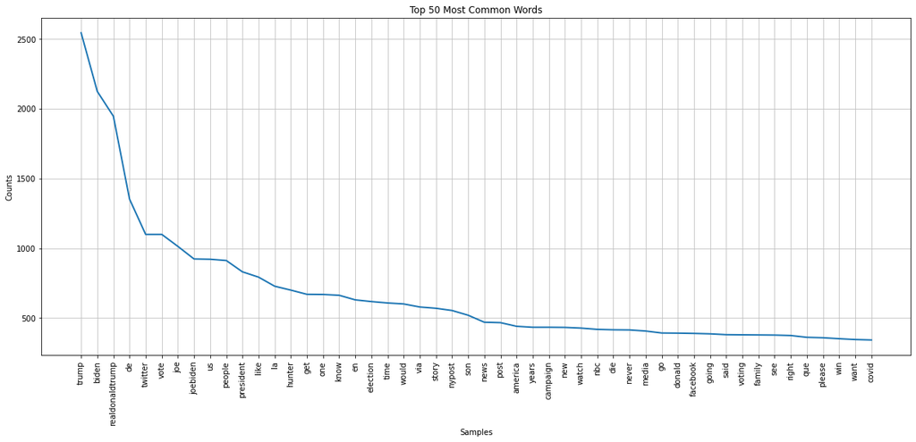

```python
plt.figure(figsize=(20,8))
term_freq(presidential_tweets)
```

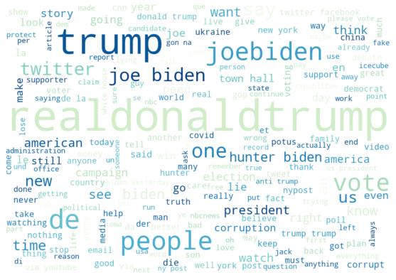

```
CPU times: user 6.82 s, sys: 124 ms, total: 6.95 s
Wall time: 6.94 s
```

```python
%%time
get_wc(presidential_tweets)
```

## Sentiment Analysis

```python
data = tweets_df[['tweet']]
```

```python
# Copying the data into a new dataframe called vader
vader = data.copy()
sentiment = vad()

# Making additional columns for sentiment score in the vader dataframe
sen = ['Positive', 'Negative', 'Neutral']
sentiments = [sentiment.polarity_scores(i) for i in vader['tweet'].values]
vader['Negative Score'] = [i['neg'] for i in sentiments]
vader['Positive Score'] = [i['pos'] for i in sentiments]
vader['Neutral Score'] = [i['neu'] for i in sentiments]
vader['Compound Score'] = [i['compound'] for i in sentiments]
score = vader['Compound Score'].values

t = []
for i in score:
    if i >= 0.05 :
        t.append('Positive')
    elif i<= -0.05 :
        t.append('Negative')
    else:
        t.append('Neutral')
vader['OverallSentiment'] = t
```

```python
vader.head()
```

|  | tweet | Negative Score | Positive Score | Neutral Score | Compound Score | OverallSentiment |
| --- | --- | --- | --- | --- | --- | --- |
| 0 | en dice que solo se preocupa por él mismo el d... | 0.0 | 0.000 | 1.000 | 0.0000 | Neutral |
| 1 | usa 2020 trump contro facebooktwitter coprono ... | 0.0 | 0.000 | 1.000 | 0.0000 | Neutral |
| 2 | asstudentused hear years ten yearsheard china ... | 0.0 | 0.122 | 0.878 | 0.3612 | Positive |
| 3 | 2 hours since last tweet maybe busy tremendous... | 0.0 | 0.000 | 1.000 | 0.0000 | Neutral |
| 4 | gettie gettierally | 0.0 | 0.000 | 1.000 | 0.0000 | Neutral |

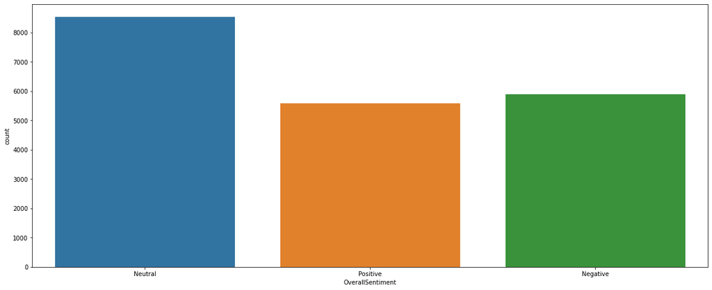

```python
plt.figure(figsize=(20,8))
sns.countplot(vader['OverallSentiment'])
```

```python
vader['hashtag']= tweets_df['hashtag']
```

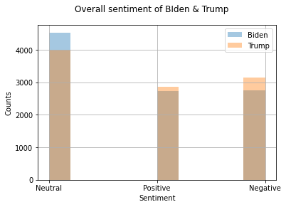

```python
vader.groupby("hashtag").OverallSentiment.hist(alpha=0.4,legend=True )
# set title and axis labels
plt.suptitle('Overall sentiment of BIden & Trump ')
plt.xlabel("Sentiment")
plt.ylabel("Counts")
```

```python
tweets_df['OverallSentiment']=vader['OverallSentiment']
```

## Models

```python
y = tweets_df['OverallSentiment'].values
X = tweets_df['tweet'].values
```

Label Encoding

```python
enc = LabelEncoder().fit(y)
y = enc.transform(y)
```

Split the data into training and testing sets

```python
X_train, X_test, y_train, y_test = train_test_split(X, y,test_size=0.30, random_state = 0)
```

Create a TFIDF vectorizer

```python
tfv = TfidfVectorizer(min_df = 3, max_features = None, strip_accents = 'unicode', analyzer = 'word', token_pattern = r'\w{1,}')

tfv.fit(list(X_train) + list(X_test))
xtrain_tfv =  tfv.transform(X_train)
xvalid_tfv = tfv.transform(X_test)
```

```python
tfv_fn = tfv.get_feature_names()
```

### Multinomial Naive Bayes

```python
mb = MultinomialNB()

classifier = mb.fit(xtrain_tfv, y_train)
mb_predicted = mb.predict(xvalid_tfv)
mb_conf_matrix = confusion_matrix(y_test, mb_predicted)
mb_acc_score = accuracy_score(y_test, mb_predicted)
mb_scores = cross_val_score(mb, xtrain_tfv, y_train, cv = 5)

print("MultinomialNB Model:", '\n')
print("Accuracy Score:", mb_acc_score*100, '\n')
print("5-Fold Cross Validation Score:")
print("%0.2f accuracy with a standard deviation of %0f" % (mb_scores.mean(), mb_scores.std()), '\n')
print("Classification Report:")
print(classification_report(y_test, mb_predicted), '\n')
print("Confusion Matrix:")
print(mb_conf_matrix)
```

```
MultinomialNB Model:

Accuracy Score: 78.2

5-Fold Cross Validation Score:
0.77 accuracy with a standard deviation of 0.007288

Classification Report:
              precision    recall  f1-score   support

           0       0.72      0.76      0.74      1732
           1       0.86      0.82      0.84      2588
           2       0.74      0.74      0.74      1680

    accuracy                           0.78      6000
   macro avg       0.77      0.78      0.77      6000
weighted avg       0.78      0.78      0.78      6000


Confusion Matrix:
[[1318  176  238]
 [ 254 2123  211]
 [ 258  171 1251]]
```

Top 10 Negative Words

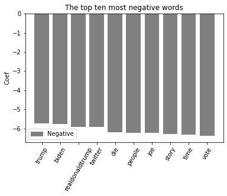

```python
cvec_coef = pd.DataFrame(mb.coef_[0], mb.coef_[1])
cvec_coef["Word"] = tfv_fn
cvec_coef = cvec_coef[cvec_coef.Word != "rt"]
cvec_coef = cvec_coef[cvec_coef.Word != "amp"]
cvec_coef = cvec_coef.reset_index()

ran = []
no_ran = []
i = 0
for k in range(0,len(cvec_coef.Word)):
    if cvec_coef[0][i] > cvec_coef[0][i]:
        no_ran.append([cvec_coef[0][i],cvec_coef["Word"][i]])
    else:
        ran.append([cvec_coef[0][i],cvec_coef["Word"][i]])
    i += 1

ran = sorted(ran, reverse = True)[:10]
no_ran = sorted(no_ran, reverse = True)[:10]
ran_tot =  no_ran + ran
ran_tot_c, ran_tot_w = [*zip(*ran_tot)]

fig = plt.figure()
ax = plt.subplot()
ax.bar(ran_tot_w, ran_tot_c, color = ['Grey'])
ax.set_xticklabels(ran_tot_w, rotation=60)
ax.set_ylabel("Coef")
ax.set_title("The top ten most negative words")
colors = {'Negative':'Grey'}
labels = list(colors.keys())
handles = [plt.Rectangle((0,0),1,1, color=colors[label]) for label in labels]
plt.legend(handles, labels)
```

[figure not shown]

```python
cvec_coef = pd.DataFrame(mb.coef_[1], mb.coef_[1])
cvec_coef["Word"] = tfv_fn
cvec_coef = cvec_coef[cvec_coef.Word != "rt"]
cvec_coef = cvec_coef[cvec_coef.Word != "amp"]
cvec_coef = cvec_coef.reset_index()

ran = []
no_ran = []
i = 0
for k in range(0,len(cvec_coef.Word)):
    if cvec_coef[0][i] > cvec_coef[0][i]:
        no_ran.append([cvec_coef[0][i],cvec_coef["Word"][i]])
    else:
        ran.append([cvec_coef[0][i],cvec_coef["Word"][i]])
    i += 1

ran = sorted(ran, reverse = True)[:10]
no_ran = sorted(no_ran, reverse = True)[:10]
ran_tot =  no_ran + ran
ran_tot_c, ran_tot_w = [*zip(*ran_tot)]

fig = plt.figure()
ax = plt.subplot()
ax.bar(ran_tot_w, ran_tot_c, color = ['Orange'])
ax.set_xticklabels(ran_tot_w, rotation=60)
ax.set_ylabel("Coef")
ax.set_title("The top ten most positive words")
colors = {'Positive':'Orange'}
labels = list(colors.keys())
handles = [plt.Rectangle((0,0),1,1, color=colors[label]) for label in labels]
plt.legend(handles, labels)
```

### Support Vector Machines

```python
svm = LinearSVC(C = 1)

classifier = svm.fit(xtrain_tfv, y_train)
svm_predicted = svm.predict(xvalid_tfv)
svm_conf_matrix = confusion_matrix(y_test, svm_predicted)
svm_acc_score = accuracy_score(y_test, svm_predicted)
svm_scores = cross_val_score(svm, xtrain_tfv, y_train, cv = 5)

print("SVM Model:", '\n')
print("Accuracy Score:", svm_acc_score*100, '\n')
print("5-Fold Cross Validation Score:")
print("%0.2f accuracy with a standard deviation of %0f" % (svm_scores.mean(), svm_scores.std()), '\n')
print("Classification Report:")
print(classification_report(y_test, svm_predicted), '\n')
print("Confusion Matrix:")
print(svm_conf_matrix)
```

```
SVM Model:

Accuracy Score: 85.95

5-Fold Cross Validation Score:
0.84 accuracy with a standard deviation of 0.001619

Classification Report:
              precision    recall  f1-score   support

           0       0.87      0.79      0.83      1732
           1       0.85      0.94      0.89      2588
           2       0.87      0.82      0.84      1680

    accuracy                           0.86      6000
   macro avg       0.86      0.85      0.85      6000
weighted avg       0.86      0.86      0.86      6000


Confusion Matrix:
[[1362  232  138]
 [  92 2421   75]
 [ 115  191 1374]]
```

Top 10 Negative Words

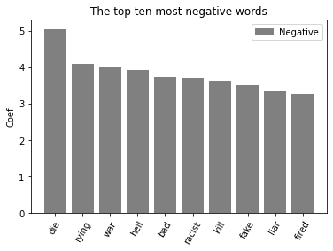

```python
cvec_coef = pd.DataFrame(svm.coef_[0], svm.coef_[1])
cvec_coef["Word"] = tfv_fn
cvec_coef = cvec_coef[cvec_coef.Word != "rt"]
cvec_coef = cvec_coef[cvec_coef.Word != "amp"]
cvec_coef = cvec_coef.reset_index()

ran = []
no_ran = []
i = 0
for k in range(0,len(cvec_coef.Word)):
    if cvec_coef[0][i] > cvec_coef[0][i]:
        no_ran.append([cvec_coef[0][i],cvec_coef["Word"][i]])
    else:
        ran.append([cvec_coef[0][i],cvec_coef["Word"][i]])
    i += 1

ran = sorted(ran, reverse = True)[:10]
no_ran = sorted(no_ran, reverse = True)[:10]
ran_tot =  no_ran + ran
ran_tot_c, ran_tot_w = [*zip(*ran_tot)]

fig = plt.figure()
ax = plt.subplot()
ax.bar(ran_tot_w, ran_tot_c, color = ['Grey'])
ax.set_xticklabels(ran_tot_w, rotation=60)
ax.set_ylabel("Coef")
ax.set_title("The top ten most negative words")
colors = {'Negative':'Grey'}
labels = list(colors.keys())
handles = [plt.Rectangle((0,0),1,1, color=colors[label]) for label in labels]
plt.legend(handles, labels)
```

[figure not shown]

```python
cvec_coef = pd.DataFrame(svm.coef_[1], svm.coef_[1])
cvec_coef["Word"] = tfv_fn
cvec_coef = cvec_coef[cvec_coef.Word != "rt"]
cvec_coef = cvec_coef[cvec_coef.Word != "amp"]
cvec_coef = cvec_coef.reset_index()

ran = []
no_ran = []
i = 0
for k in range(0,len(cvec_coef.Word)):
    if cvec_coef[0][i] > cvec_coef[0][i]:
        no_ran.append([cvec_coef[0][i],cvec_coef["Word"][i]])
    else:
        ran.append([cvec_coef[0][i],cvec_coef["Word"][i]])
    i += 1

ran = sorted(ran, reverse = True)[:10]
no_ran = sorted(no_ran, reverse = True)[:10]
ran_tot =  no_ran + ran
ran_tot_c, ran_tot_w = [*zip(*ran_tot)]

fig = plt.figure()
ax = plt.subplot()
ax.bar(ran_tot_w, ran_tot_c, color = ['Orange'])
ax.set_xticklabels(ran_tot_w, rotation=60)
ax.set_ylabel("Coef")
ax.set_title("The top ten most positive words")
colors = {'Positive':'Orange'}
labels = list(colors.keys())
handles = [plt.Rectangle((0,0),1,1, color=colors[label]) for label in labels]
plt.legend(handles, labels)
```

# Conclusion

Now that we had a general overview of the dataset and the information contained, we moved forward and used the Vader Sentiment Analysis tool to find out the emotional sentiment behind each tweet by focusing on the polarity measures of the word choices. The vader tool showed that overall, most of the tweets analyzed seemed to be more neutral in tone, but those that did have a positive or negative sentiment more often included #DonaldTrump.